# **Project 2 - Netflix Titles Classification**

### **Introduce the problem**

New movies and shows are constantly produced that it's hard to keep up with what television is worth watching. Another major issue is that many people may not know what to watch, and what genre they are interested in. If they have an idea of what they want to watch, maybe newer television might not have a specific genre attached to it. I am going to look for a way for Netflix users to identify/search titles if they do not have all information of a title they are interested in. For example, the user should be able to understand where a Netflix title is based from using other relevant data the application may provide.

### **Introduce the data**

To solve this problem, we need to see a dataset of movies and tv shows on Netflix, and crucial aspects that can categorize each item. This dataset of 8,807 rows and 12 columns provides information on type, title, director, rating, duration, description and other similar factors that can describe a movie or TV show.

We will start by importing this dataset and installing necessary datasets.

```python
!pip install pandas matplotlib
```

```python
import pandas as pd
import numpy as np
import matplotlib.pyplot as plt
```

```python
titles_df = pd.read_csv("data/netflix_titles.csv")
```

Let's see a preview of the dataset:

```python
titles_df.head()
```

|  | show_id | type | title | director | cast | country | date_added | release_year | rating | duration | listed_in | description |
| --- | --- | --- | --- | --- | --- | --- | --- | --- | --- | --- | --- | --- |
| 0 | s1 | Movie | Dick Johnson Is Dead | Kirsten Johnson | NaN | United States | September 25, 2021 | 2020 | PG-13 | 90 min | Documentaries | As her father nears the end of his life, filmm... |
| 1 | s2 | TV Show | Blood & Water | NaN | Ama Qamata, Khosi Ngema, Gail Mabalane, Thaban... | South Africa | September 24, 2021 | 2021 | TV-MA | 2 Seasons | International TV Shows, TV Dramas, TV Mysteries | After crossing paths at a party, a Cape Town t... |
| 2 | s3 | TV Show | Ganglands | Julien Leclercq | Sami Bouajila, Tracy Gotoas, Samuel Jouy, Nabi... | NaN | September 24, 2021 | 2021 | TV-MA | 1 Season | Crime TV Shows, International TV Shows, TV Act... | To protect his family from a powerful drug lor... |
| 3 | s4 | TV Show | Jailbirds New Orleans | NaN | NaN | NaN | September 24, 2021 | 2021 | TV-MA | 1 Season | Docuseries, Reality TV | Feuds, flirtations and toilet talk go down amo... |
| 4 | s5 | TV Show | Kota Factory | NaN | Mayur More, Jitendra Kumar, Ranjan Raj, Alam K... | India | September 24, 2021 | 2021 | TV-MA | 2 Seasons | International TV Shows, Romantic TV Shows, TV ... | In a city of coaching centers known to train I... |

### **Pre-processing**

As we can see on the first row, there are nulls in this dataset. We will need to make sure we fill them with relevant data or remove them so we can actually use this set.

```python
titles_df.isna().sum()
```

```
show_id            0
type               0
title              0
director        2634
cast             825
country          831
date_added        10
release_year       0
rating             4
duration           3
listed_in          0
description        0
dtype: int64
```

The most common nulls come from the director column. We will handle that by making it clear that there is no director mentioned in the title.

```python
titles_df['director'] = titles_df['director'].fillna("N/A")
titles_df['country'] = titles_df['country'].fillna("N/A")
titles_df['cast'] = titles_df['cast'].fillna("N/A")
titles_df['date_added'] = titles_df['date_added'].fillna("N/A")
titles_df['rating'] = titles_df['rating'].fillna("N/A")
titles_df['duration'] = titles_df['duration'].fillna("N/A")
```

```python
titles_df.head()
```

|  | show_id | type | title | director | cast | country | date_added | release_year | rating | duration | listed_in | description |
| --- | --- | --- | --- | --- | --- | --- | --- | --- | --- | --- | --- | --- |
| 0 | s1 | Movie | Dick Johnson Is Dead | Kirsten Johnson | N/A | United States | September 25, 2021 | 2020 | PG-13 | 90 min | Documentaries | As her father nears the end of his life, filmm... |
| 1 | s2 | TV Show | Blood & Water | N/A | Ama Qamata, Khosi Ngema, Gail Mabalane, Thaban... | South Africa | September 24, 2021 | 2021 | TV-MA | 2 Seasons | International TV Shows, TV Dramas, TV Mysteries | After crossing paths at a party, a Cape Town t... |
| 2 | s3 | TV Show | Ganglands | Julien Leclercq | Sami Bouajila, Tracy Gotoas, Samuel Jouy, Nabi... | N/A | September 24, 2021 | 2021 | TV-MA | 1 Season | Crime TV Shows, International TV Shows, TV Act... | To protect his family from a powerful drug lor... |
| 3 | s4 | TV Show | Jailbirds New Orleans | N/A | N/A | N/A | September 24, 2021 | 2021 | TV-MA | 1 Season | Docuseries, Reality TV | Feuds, flirtations and toilet talk go down amo... |
| 4 | s5 | TV Show | Kota Factory | N/A | Mayur More, Jitendra Kumar, Ranjan Raj, Alam K... | India | September 24, 2021 | 2021 | TV-MA | 2 Seasons | International TV Shows, Romantic TV Shows, TV ... | In a city of coaching centers known to train I... |

Let's make sure all nulls are handled!

```python
titles_df.isna().sum()
```

```
show_id         0
type            0
title           0
director        0
cast            0
country         0
date_added      0
release_year    0
rating          0
duration        0
listed_in       0
description     0
dtype: int64
```

### **Data Understanding/Visualization**

Let's get an idea of what the most common country is that develops Netflix titles. We will also look into ratings between TV shows and movies, and see which one is higher.

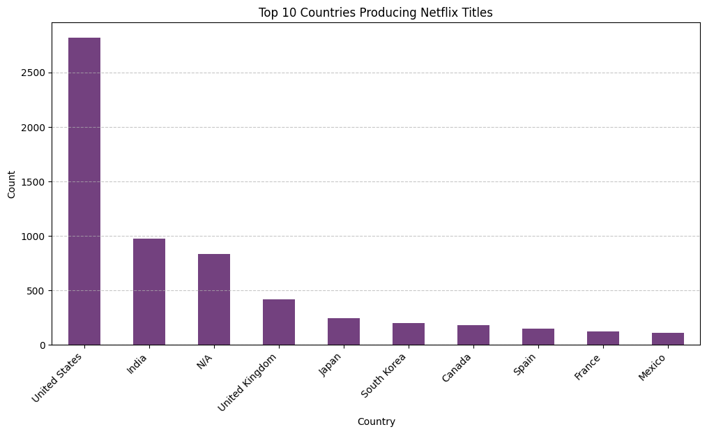

```python
# Count occurrences of each country and select the top 10
top_countries = titles_df['country'].value_counts().head(10)

# Plot the data
plt.figure(figsize=(12, 6))
top_countries.plot(kind='bar', colormap='viridis', alpha=0.75)

# Customizing the plot
plt.title("Top 10 Countries Producing Netflix Titles")
plt.xlabel("Country")
plt.ylabel("Count")
plt.xticks(rotation=45, ha="right")
plt.grid(axis="y", linestyle="--", alpha=0.7)

# Show the plot
plt.show()
```

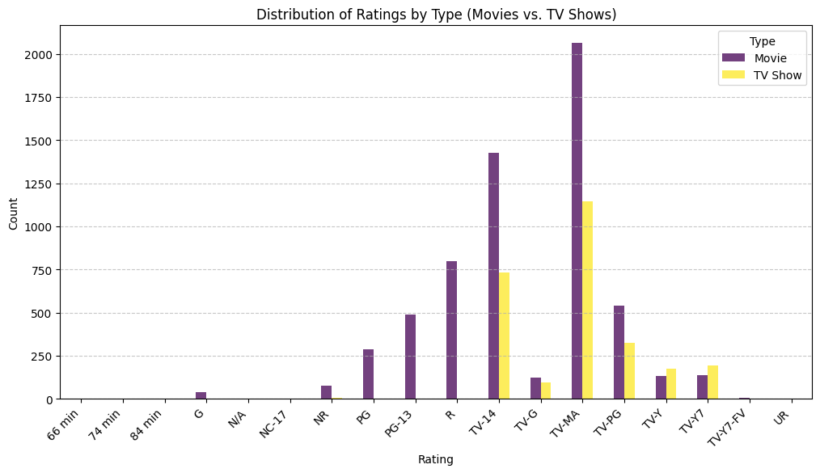

```python
# Count occurrences of each rating for Movies and TV Shows separately
rating_counts = titles_df.groupby(['type', 'rating']).size().unstack(fill_value=0)

# Plot the data
rating_counts.T.plot(kind='bar', figsize=(12, 6), alpha=0.75, colormap='viridis')

# Customizing the plot
plt.title("Distribution of Ratings by Type (Movies vs. TV Shows)")
plt.xlabel("Rating")
plt.ylabel("Count")
plt.xticks(rotation=45, ha="right")
plt.legend(title="Type")
plt.grid(axis="y", linestyle="--", alpha=0.7)

# Show the plot
plt.show()
```

### **Modeling**

Based on the graphs above, we can come to the conclusion that the United States produces the most Netflix titles and that the most popular rating is TV-MA for movies and TV shows.

The goal on this project is to predict a Netflix title's origin based on other features provided. For example, I want to find what features can classify a United States title from a title from Canada and how we can use an algorithm to determine this.

To achieve this goal, I will be using a Random Forest Classification, due to the size of this dataset and the many columns of data we can use to identify unique titles.

To start, we will select the features that we want to use and the target column we want to identify titles with.

```python
# Selecting features and target variable
features = titles_df[['type', 'rating', 'release_year', 'listed_in']]
target = titles_df['country']

# Encoding categorical variables using one-hot encoding
features = pd.get_dummies(features)
```

To make it easier for us to understand the target column and being able to identify countries for the Random Forest, we will use Label Encoder to understand countries as numbers.

```python
# Import necessary sklearn features
from sklearn.model_selection import train_test_split
from sklearn.ensemble import RandomForestClassifier
from sklearn.tree import plot_tree
from sklearn.preprocessing import LabelEncoder, OneHotEncoder
from sklearn.metrics import accuracy_score, classification_report
```

```python
# Encode target variable (countries) using Label Encoding
label_encoder = LabelEncoder()
target = label_encoder.fit_transform(target)
```

Now we will get into the training/testing sets:

```python
X_train, X_test, y_train, y_test = train_test_split(features, target, test_size=0.2, random_state=42)
```

We can now set up the Random Forest model and train it!

```python
rf_model = RandomForestClassifier(n_estimators=100, random_state=42)
rf_model.fit(X_train, y_train)
```

```
RandomForestClassifier(random_state=42)
```

### **Evaluation**

Let's make predictions and evaluate the model based on the training.

```python
y_pred = rf_model.predict(X_test)
```

[figure not shown]

```python
# Select a tree from the Random Forest
tree = rf_model.estimators_[0]

# Limit the depth for better visualization
plt.figure(figsize=(60, 32))
plot_tree(tree, feature_names=features.columns, class_names=label_encoder.classes_, filled=True, max_depth=1)
plt.show()
```

Below is the accuracy of the algorithm with a classification report:

```python
print(classification_report(y_test, y_pred, labels=np.unique(y_test)))
```

```
              precision    recall  f1-score   support

           2       0.00      0.00      0.00        10
           4       0.00      0.00      0.00         1
           5       0.00      0.00      0.00         1
           6       0.00      0.00      0.00         1
           9       0.00      0.00      0.00         1
          12       0.00      0.00      0.00         1
          13       0.00      0.00      0.00         1
          15       0.11      0.05      0.07        20
          19       0.00      0.00      0.00         1
          21       0.00      0.00      0.00         1
          25       0.00      0.00      0.00         1
          26       0.00      0.00      0.00         2
          30       0.00      0.00      0.00         1
```

[output cut: 211 more lines]

[output not shown]

Overall, based on this dataset and the accuracy after using the Random Forest, this wasn't the best algorithm to use to classify Netflix titles by country. Although using the one tree as an example led us to finding the right class, it was too broad of a classification. Overall, the accuracy average was under 0.50, and there was many moments where the accuracy reached 0.00. Due to the size of this dataset and variety in the rows, it is difficult to have an accurate classification.

### **Impact**

This project can be used to ideally find the highest grossing country for producing Netflix titles. It can also be used to eventually recommend titles based on a user's interests, but that would involve machine learning and more intense training to reach that level. As of right now, with the Random Forest classification algorithm, this project does not have much social impact, but it can eventually inform users of what features they should look for if they are looking for a title based on a certain country.

### **References**

[Random Forest W3Schools](https://www.geeksforgeeks.org/random-forest-algorithm-in-machine-learning/)

[ChatGPT - Classification and Data Visualization adjustments](https://www.chatgpt.com/)